# class17

Sanghun Lee

6/17/2019

# Introduction and loading data

Cytoscape is a visualization tool that allows analyzation of data with a network-like map.

For this assignment, the file “galFiltered.sif” was imported and loaded to Cytoscape.

```r
gal.data <- read.csv("galExpData.csv")
head(gal.data)
```

```
##      GENE  COMMON gal1RGexp gal4RGexp gal80Rexp  gal1RGsig  gal4RGsig
## 1 YHR051W    COX6    -0.034     0.111    -0.304 0.37572000 0.01562400
## 2 YHR124W   NDT80    -0.090     0.007    -0.348 0.27146000 0.96433000
## 3 YKL181W    PRS1    -0.167    -0.233     0.112 0.00627120 0.00078940
## 4 YGR072W    UPF3     0.245    -0.471     0.787 0.00041045 0.00075178
## 5 YHL020C    OPI1     0.174    -0.015     0.151 0.00014016 0.71912000
## 6 YGR145W YGR145W     0.387    -0.577    -0.088 0.00537920 0.00827330
##    gal80Rsig
## 1 7.9134e-06
## 2 3.4476e-01
## 3 1.4406e-01
## 4 1.3713e-05
## 5 1.5395e-02
## 6 7.6418e-01
```

By loading our data, we can see that the columns tell us different data points corresponding to each gene.

We can use this to better organize our data.

# Setting up Cytoscape and R

At this point, I’ve already completed the graphic manipulation portion of Cytoscape. Refer to class handout page for more details.

Now it remains to setup R so that it can read .cys (Cytoscape) files.

*(Installation of RCy3 package should proceed through BiocManager::install. Search “Bioconductor”, or type **install.packages(“BiocManager”)** for more details.)*

```r
library(RCy3)
library(igraph)
library(RColorBrewer)

cytoscapePing() #Check to see if Cytoscape is online
cytoscapeVersionInfo() #Check Cytoscape version
```

# Testing different capabilities of our loaded R packages.

*Creating a simple Cytoscape graph*

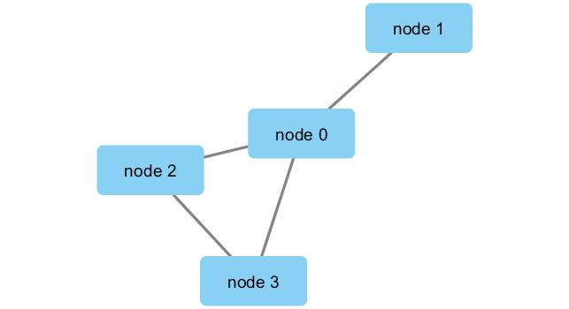

```r
s <- makeSimpleGraph()
createNetworkFromGraph(s, "myGraph")
```

*Switching Styles*

```
##                 message
## "Visual Style applied."
```

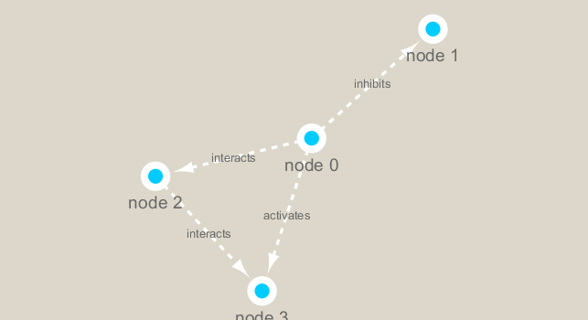

# Reading our metagenomics data

```r
prok.cor.vir <- read.delim("virus_prok_cor_abundant.tsv", stringsAsFactors = F)
head(prok.cor.vir)
```

```
##       Var1          Var2    weight
## 1  ph_1061 AACY020068177 0.8555342
## 2  ph_1258 AACY020207233 0.8055750
## 3  ph_3164 AACY020207233 0.8122517
## 4  ph_1033 AACY020255495 0.8487498
## 5 ph_10996 AACY020255495 0.8734617
## 6 ph_11038 AACY020255495 0.8740782
```

```r
# Strings As Factors False?
# This means that the subsequent character data (like name, type, etc.) are treated as character values, and not as a qualitative data.
```

```r
g <- graph.data.frame(prok.cor.vir, directed = F)
class(g)
```

```
## [1] "igraph"
```

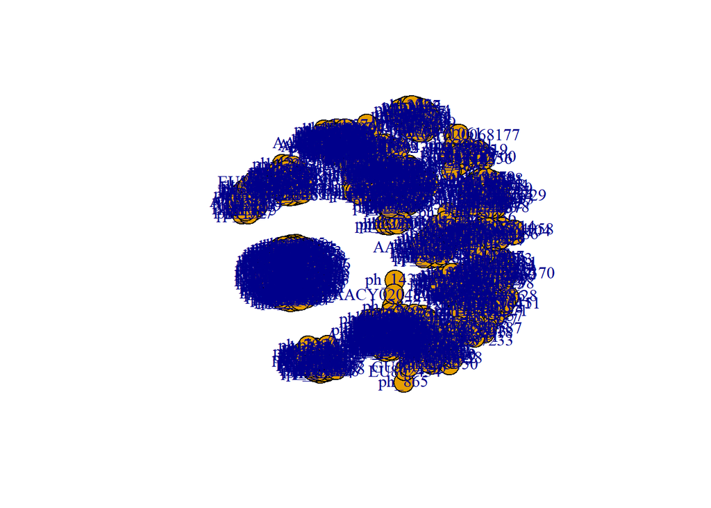

```r
plot (g)
```

Cleaning up the messy graph. To do this, we will use the parameters *vertex.label = NA* and *vertex.size = n*. The first parameter removes the variable labels, while the second one manipulates the sizes of the nodes.

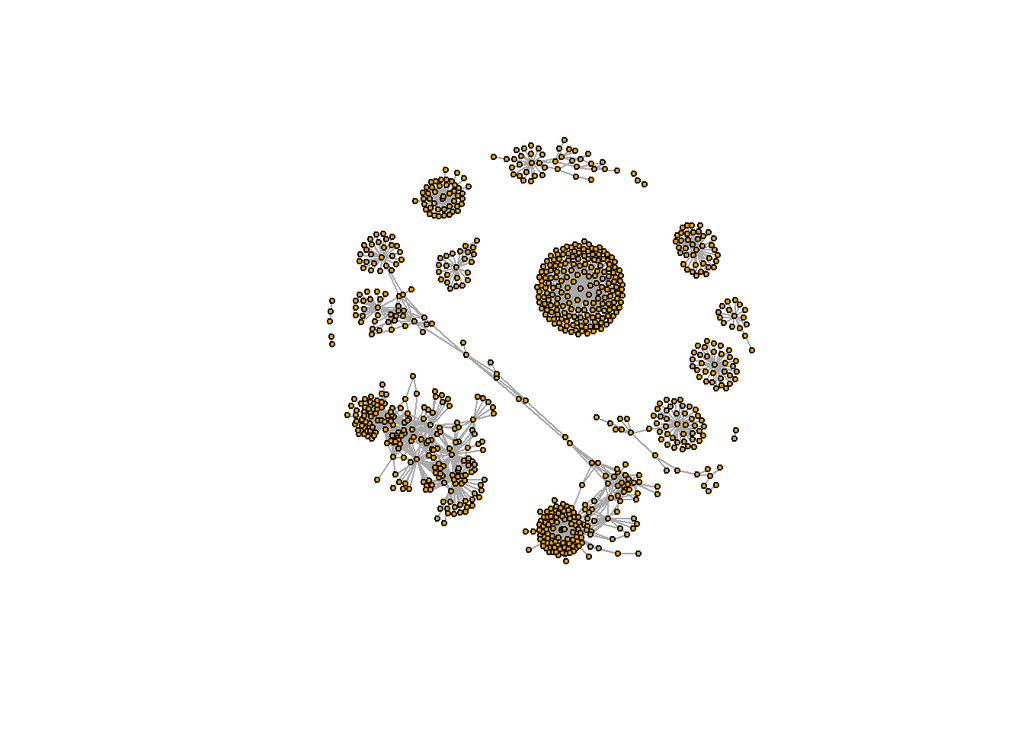

```r
plot(g, vertex.size = 3, vertex.label = NA)
```

# ggPlot usage

One of R’s strongest packages is ggPlot. Therefore, doing work with other packages may feel a little lackluster. We will use ggPlot to represent our metagenomics data.

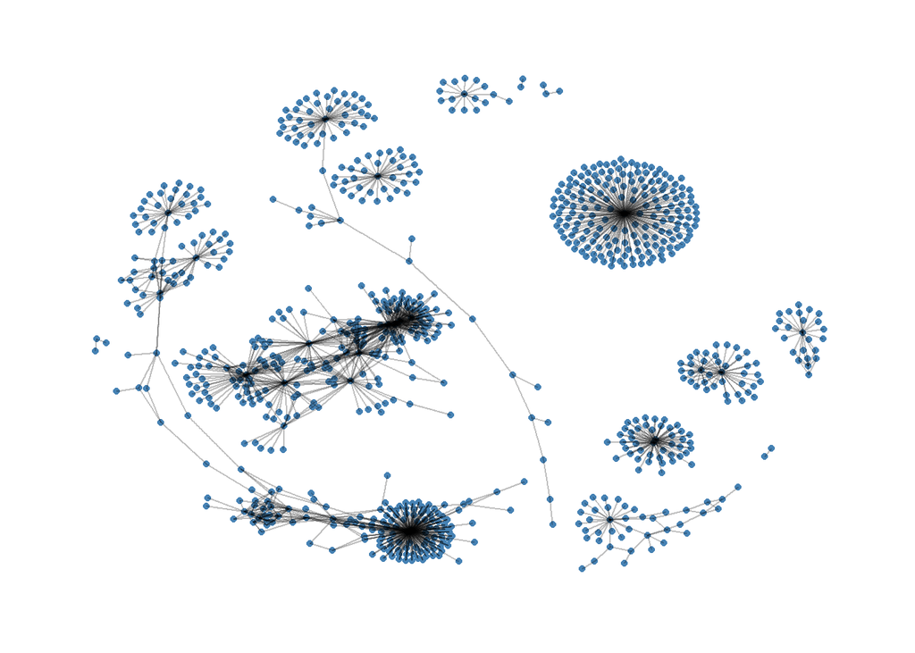

```r
library(ggraph)

ggraph(g, layout = 'auto') +
  geom_node_point(color = 'steelblue') +
  geom_edge_link(alpha = 0.25) +
  theme_graph()
```

*Loading our data to Cytoscape & looking at attributes*

```r
createNetworkFromIgraph(g, "myIgraph")
```

```
## Loading data...
## Applying default style...
## Applying preferred layout...
```

```
## networkSUID
##       24222
```

```r
V(g)
```

```
## + 845/845 vertices, named, from e468059:
##   [1] ph_1061       ph_1258       ph_3164       ph_1033       ph_10996
##   [6] ph_11038      ph_11040      ph_11048      ph_11096      ph_1113
##  [11] ph_1208       ph_13207      ph_1346       ph_14679      ph_1572
##  [16] ph_16045      ph_1909       ph_1918       ph_19894      ph_2117
##  [21] ph_2231       ph_2363       ph_276        ph_2775       ph_2798
##  [26] ph_3217       ph_3336       ph_3493       ph_3541       ph_3892
##  [31] ph_4194       ph_4602       ph_4678       ph_484        ph_4993
##  [36] ph_4999       ph_5001       ph_5010       ph_5286       ph_5287
##  [41] ph_5302       ph_5321       ph_5643       ph_6441       ph_654
##  [46] ph_6954       ph_7389       ph_7920       ph_8039       ph_8695
## + ... omitted several vertices
```

```r
E(g)
```

```
## + 1544/1544 edges from e468059 (vertex names):
##  [1] ph_1061 --AACY020068177 ph_1258 --AACY020207233
##  [3] ph_3164 --AACY020207233 ph_1033 --AACY020255495
##  [5] ph_10996--AACY020255495 ph_11038--AACY020255495
##  [7] ph_11040--AACY020255495 ph_11048--AACY020255495
##  [9] ph_11096--AACY020255495 ph_1113 --AACY020255495
## [11] ph_1208 --AACY020255495 ph_13207--AACY020255495
## [13] ph_1346 --AACY020255495 ph_14679--AACY020255495
## [15] ph_1572 --AACY020255495 ph_16045--AACY020255495
## [17] ph_1909 --AACY020255495 ph_1918 --AACY020255495
## [19] ph_19894--AACY020255495 ph_2117 --AACY020255495
## + ... omitted several edges
```

# Network community detection

Using *cluster_edge_betweeness* function will allow us to look at the different subgraphs that exist between clusters of nodes. We will then plot the result to graphically represent our data.

```r
cb <- cluster_edge_betweenness(g)
cb
```

```
## IGRAPH clustering edge betweenness, groups: 18, mod: 0.82
## + groups:
##   $`1`
##   [1] "ph_1061"       "AACY020068177"
##
##   $`2`
##    [1] "ph_1258"       "ph_5861"       "ph_7172"       "ph_11569"
##    [5] "ph_1291"       "ph_1600"       "ph_2702"       "ph_5790"
##    [9] "ph_5858"       "ph_7594"       "ph_7816"       "ph_784"
##   [13] "ph_1359"       "ph_1534"       "ph_1874"       "ph_2465"
##   [17] "ph_5453"       "ph_900"        "ph_908"        "ph_811"
##   [21] "ph_1367"       "ph_1452"       "ph_1458"       "ph_1723"
##   + ... omitted several groups/vertices
```

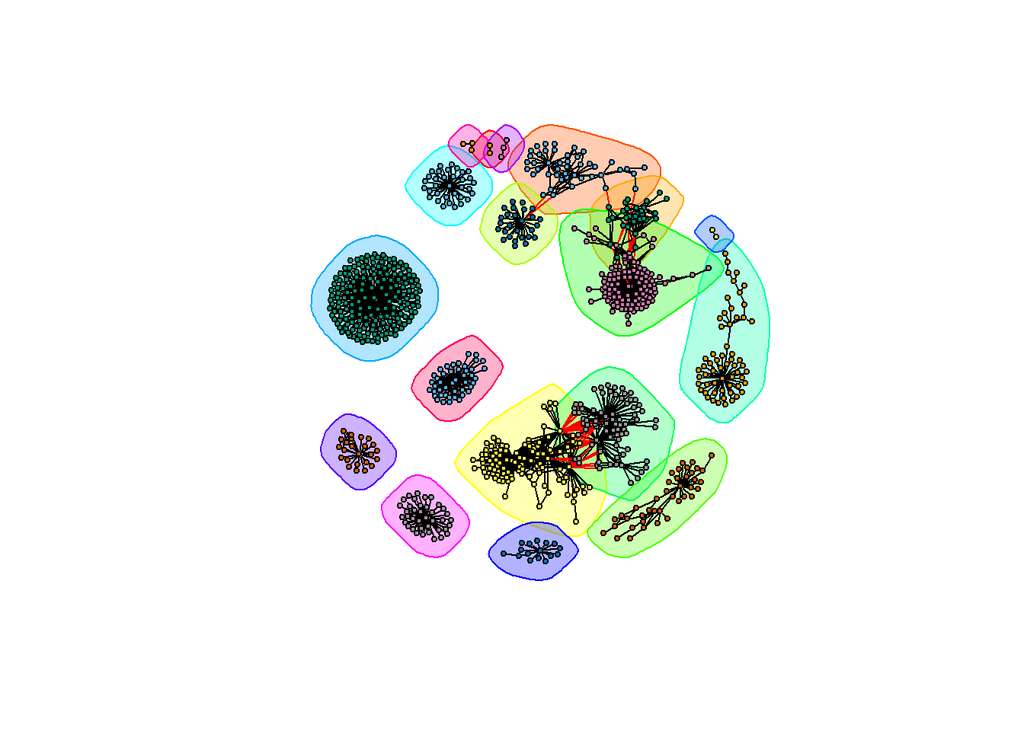

```r
plot(cb, y = g, vertex.label = NA, vertex.size = 3)
```

# Centrality analysis

Centrality gives an estimation of how important a node is for the connectivity of a network. Installed the package called “BBmisc” to visualize this part.

```r
pr <- page_rank(g)
head(pr$vector)
```

```
##      ph_1061      ph_1258      ph_3164      ph_1033     ph_10996
## 0.0011834320 0.0011599483 0.0019042088 0.0005788564 0.0005769663
##     ph_11038
## 0.0005745460
```

*Centrality visualization*

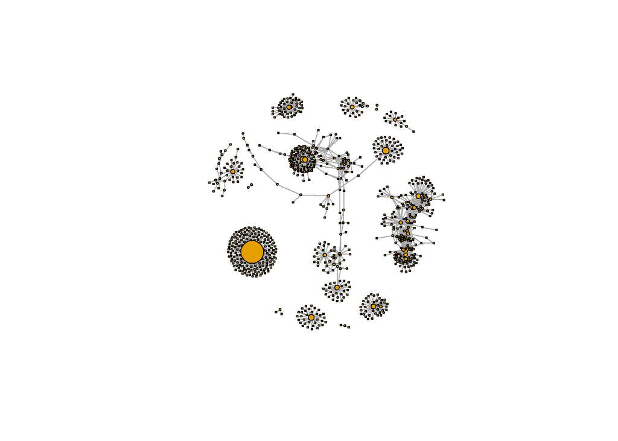

```r
v.size <- BBmisc::normalize(pr$vector, range = c(2,20), method = 'range')
plot(g, vertex.size = v.size, vertex.label = NA)
```

# Betweenness analysis

Betweenness centrality is based on shortest paths.

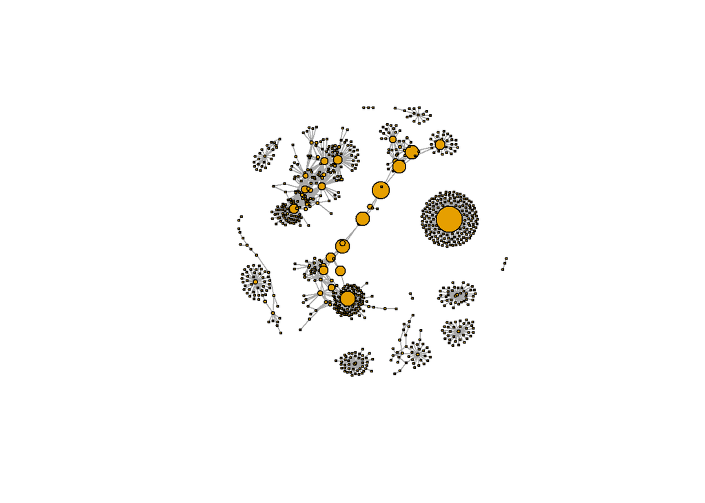

```r
b <- betweenness(g)
v.size <- BBmisc::normalize(b, range = c(2,20), method = 'range')

plot(g, vertex.size = v.size, vertex.label = NA)
```

# Taxonomic classification for network annotation

Now we will start to classify our data points. Loading up and taking a look at our data yields:

```
##   first_sheet.Phage_id first_sheet.Phage_id_network phage_affiliation
## 1        109DCM_115804                       ph_775              <NA>
## 2        109DCM_115804                       ph_775              <NA>
## 3        109DCM_115804                       ph_775              <NA>
## 4        109DCM_115804                       ph_775              <NA>
## 5        109DCM_115804                       ph_775              <NA>
## 6        109DCM_115804                       ph_775              <NA>
##   Domain DNA_or_RNA Tax_order Tax_subfamily Tax_family Tax_genus
## 1   <NA>       <NA>      <NA>          <NA>       <NA>      <NA>
## 2   <NA>       <NA>      <NA>          <NA>       <NA>      <NA>
## 3   <NA>       <NA>      <NA>          <NA>       <NA>      <NA>
## 4   <NA>       <NA>      <NA>          <NA>       <NA>      <NA>
## 5   <NA>       <NA>      <NA>          <NA>       <NA>      <NA>
## 6   <NA>       <NA>      <NA>          <NA>       <NA>      <NA>
##   Tax_species
## 1        <NA>
## 2        <NA>
## 3        <NA>
## 4        <NA>
## 5        <NA>
## 6        <NA>
```

```
##    Accession_ID  Kingdom         Phylum          Class             Order
## 1 AACY020068177 Bacteria    Chloroflexi   SAR202 clade marine metagenome
## 2 AACY020125842  Archaea  Euryarchaeota Thermoplasmata Thermoplasmatales
## 3 AACY020187844  Archaea  Euryarchaeota Thermoplasmata Thermoplasmatales
## 4 AACY020105546 Bacteria Actinobacteria Actinobacteria             PeM15
## 5 AACY020281370  Archaea  Euryarchaeota Thermoplasmata Thermoplasmatales
## 6 AACY020147130  Archaea  Euryarchaeota Thermoplasmata Thermoplasmatales
##              Family             Genus Species
## 1              <NA>              <NA>    <NA>
## 2   Marine Group II marine metagenome    <NA>
## 3   Marine Group II marine metagenome    <NA>
## 4 marine metagenome              <NA>    <NA>
## 5   Marine Group II marine metagenome    <NA>
## 6   Marine Group II marine metagenome    <NA>
```

Loading up genomic ID.

```r
gene.nodes <- as.data.frame(vertex.attributes(g), stringsAsFactors = FALSE)
head(gene.nodes)
```

```
##       name
## 1  ph_1061
## 2  ph_1258
## 3  ph_3164
## 4  ph_1033
## 5 ph_10996
## 6 ph_11038
```

Merge and polishing data

```r
z <- bac.id[,c("Accession_ID", "Kingdom", "Phylum", "Class")]
n <- merge(gene.nodes, z, by.x = 'name', by.y = "Accession_ID", all.x = T)
head(n)
```

```
##            name  Kingdom          Phylum               Class
## 1 AACY020068177 Bacteria     Chloroflexi        SAR202 clade
## 2 AACY020207233 Bacteria Deferribacteres     Deferribacteres
## 3 AACY020255495 Bacteria  Proteobacteria Gammaproteobacteria
## 4 AACY020288370 Bacteria  Actinobacteria      Acidimicrobiia
## 5 AACY020396101 Bacteria  Actinobacteria      Acidimicrobiia
## 6 AACY020398456 Bacteria  Proteobacteria Gammaproteobacteria
```

```r
colnames(n)
```

```
## [1] "name"    "Kingdom" "Phylum"  "Class"
```

```r
colnames(phage.id)
```

```
##  [1] "first_sheet.Phage_id"         "first_sheet.Phage_id_network"
##  [3] "phage_affiliation"            "Domain"
##  [5] "DNA_or_RNA"                   "Tax_order"
##  [7] "Tax_subfamily"                "Tax_family"
##  [9] "Tax_genus"                    "Tax_species"
```

```r
y <- phage.id[, c("first_sheet.Phage_id_network", "phage_affiliation", "Tax_order", "Tax_subfamily")]

x <- merge(x = n, y = y, by.x = "name", by.y = "first_sheet.Phage_id_network", all.x = T)

x <- x[!duplicated((x$name)),]
head(x)
```

```
##            name  Kingdom          Phylum               Class
## 1 AACY020068177 Bacteria     Chloroflexi        SAR202 clade
## 2 AACY020207233 Bacteria Deferribacteres     Deferribacteres
## 3 AACY020255495 Bacteria  Proteobacteria Gammaproteobacteria
## 4 AACY020288370 Bacteria  Actinobacteria      Acidimicrobiia
## 5 AACY020396101 Bacteria  Actinobacteria      Acidimicrobiia
## 6 AACY020398456 Bacteria  Proteobacteria Gammaproteobacteria
##   phage_affiliation Tax_order Tax_subfamily
## 1              <NA>      <NA>          <NA>
## 2              <NA>      <NA>          <NA>
## 3              <NA>      <NA>          <NA>
## 4              <NA>      <NA>          <NA>
## 5              <NA>      <NA>          <NA>
## 6              <NA>      <NA>          <NA>
```

```r
gene.nodes <- x
```

The addition of Kingdom, Phyla, and Class to our data point allows us to have a better organized data table. It looks pretty, and we should like pretty data tables!

# Sending our network out to Cytoscape

Clearing our Cytoscape program and prepping data

```r
deleteAllNetworks()

gene.edges <- data.frame(igraph::as_edgelist(g))

colnames(gene.nodes)[1] <- "id"

colnames(gene.edges) <- c("source", "target")
gene.edges$weight <- igraph::edge.attributes(g)$weight

createNetworkFromDataFrames(gene.nodes, gene.edges, title = "Tara_Oceans")
```

```
## Loading data...
## Applying default style...
## Applying preferred layout...
```

```
## networkSUID
##       29028
```

# Final result visualization with ggplot

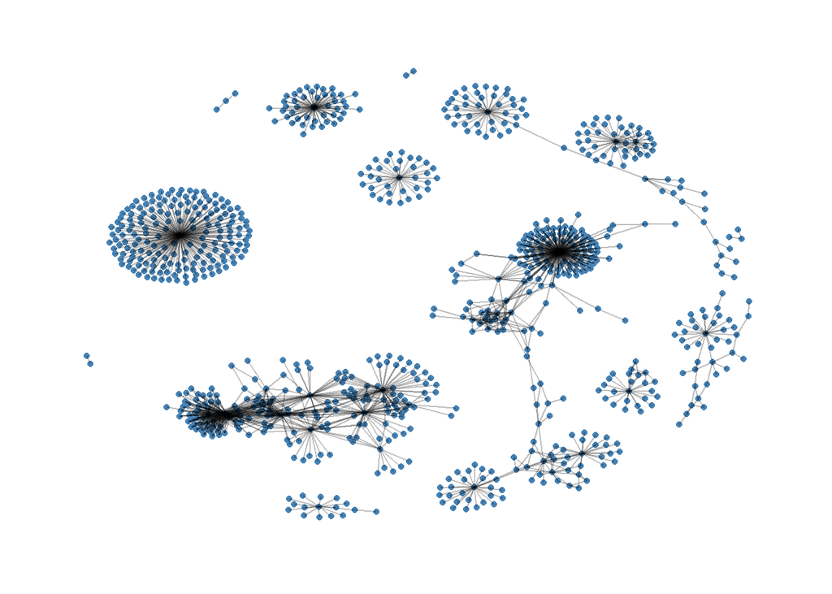

```r
ig <- createIgraphFromNetwork("Tara_Oceans")

ggraph(ig, layout = 'auto')+
  geom_node_point(color = 'steelblue')+
  geom_edge_link(alpha = 0.25)+
  theme_graph()
```

*Import final result image from Cytoscape for comparison*

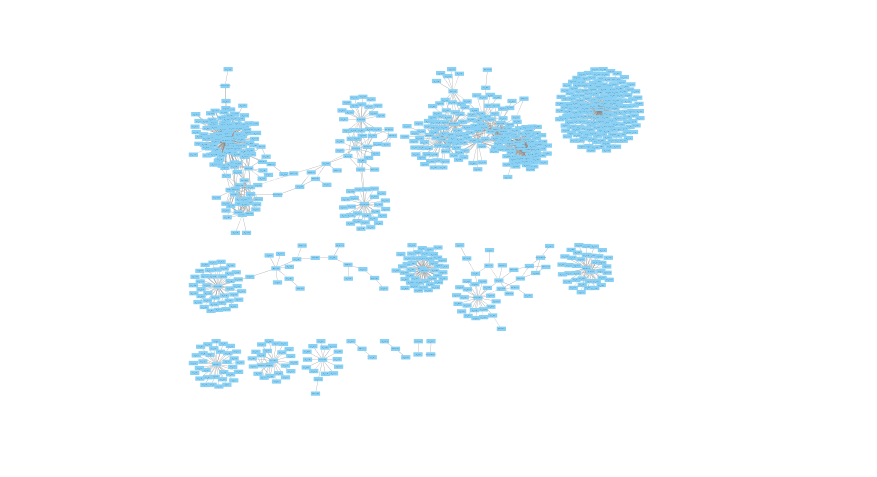

```r
knitr::include_graphics("./Tara_Oceans.png")
```